# UE 11 – Calcul Différentiel, Intégral et Stochastique

## Charge de travail

Les étudiants ont passé en moyenne :

- 16h30 à étudier le cours,
- 16h40 à faire des exercices,
- 15h20 à travailler sur le projet numérique.

Si l'on affecte 50% du temps passé sur le projet numérique à l'enseignement informatique (comme annoncé), et que l'on rajoute aux heures déjà listées les 3 heures d'examen et les 20 minutes de soutenance de projet numérique, on obtient un temps de travail total moyen de **44 heures**, très proche de la moyenne théorique de 45 heures affectée par le cursus à l'enseignement.

Ce volume de travail varie considérablement d'un étudiant à l'autre, avec un écart-type de ~10 heures. Le facteur explicatif principal est la filière d'origine, comme le montre la composition des populations ayant eu besoin de moins de 35h et celle ayant eu besoin de plus de 55h. Dans la première catégorie on trouve une très marge majorité de MP (presque 3/4), contre moins d'un quart dans la seconde catégorie. Inversement, aucun AST, ATS, TSI ou PT n'est présent dans la première catégorie, alors qu'ils sont surreprésentés dans la seconde (plus d'un quart de la population). Les proportions de PSI et de PC varient moins d'une catégorie à l'autre.

```python
nan = np.nan
li = df["Temps total consacré à l'étude du cours (en présence des enseignants ou non)"]
l =  ['10',
 nan,
 '15',
 '12',
 '12',
 '18',
 '10',
 '24',
 '24',
 nan,
 'Je ne sais pas, mais je passe beaucoup de temps à relire le cours et à le ficher',
 '15',
 "24",
 '18',
 '16',
 '24',
 '15',
 '16',
 '12',
 '13',
 '16',
 '20',
 '12',
 '22',
 nan,
 '15',
 '15',
 "10",
 '12',
 nan,
 '27.5',
 '4',
 '12',
 '14',
 '21',
 '20',
 '26',
 '10',
 '16',
 '24',
 '15',
 '9',
 nan,
 '10',
 '10',
 '15',
 "13.5",
 '10',
 '20',
 "20",
 nan,
 '18',
 '19',
 '20',
 '12',
 '18',
 '20',
 '24',
 "20",
 '12 ',
 '11',
 '18',
 '30',
 '10',
 '12',
 '20',
 'Non mesuré : probablement dans la moyenne conseillée',
 '25',
 'Je ne saurais donner de temps...',
 '9',
 '17',
 '13',
 '25',
 '12',
 '17',
 '15',
 "20",
 '15',
 '24',
 '20',
 '12',
 '18',
 '24',
 '16',
 "20",
 '24',
 '20',
 '13',
 '15',
 '16',
 '22',
 '16',
 '12',
 '16',
 '10.5',
 nan,
 '10',
 '15',
 '20',
 '15',
 '12',
 '14',
 '15.5',
 '24',
 '14',
 '20',
 '20']
time_old_new = []
for i, x in enumerate(l):
    try:
        l[i] = float(x)
    except:
        l[i] = np.nan
    time_old_new.append([li[i], l[i]])
df["Temps total consacré à l'étude du cours (en présence des enseignants ou non)"] = l

with pd.option_context('display.max_rows', None, 'display.max_columns', None):
    display(pd.DataFrame(time_old_new, columns=["Original", "Transcrit"]))
```

|  | Original | Transcrit |
| --- | --- | --- |
| 0 | 10h | 10.0 |
| 1 | NaN | NaN |
| 2 | 15 | 15.0 |
| 3 | 12h | 12.0 |
| 4 | 12 | 12.0 |
| 5 | 18h | 18.0 |
| 6 | 10 | 10.0 |
| 7 | 24 | 24.0 |
| 8 | 24 | 24.0 |
| 9 | NaN | NaN |
| 10 | Je ne sais pas, mais je passe beaucoup de temp... | NaN |
| 11 | 15h | 15.0 |
| 12 | 12h de cours + 12h d'apprentissage perso = 24h | 24.0 |
| 13 | 18h | 18.0 |
| 14 | 16 | 16.0 |
| 15 | 24 | 24.0 |
| 16 | 15h | 15.0 |
| 17 | 16 | 16.0 |
| 18 | 12 | 12.0 |
| 19 | 13h | 13.0 |
| 20 | 16h | 16.0 |
| 21 | 20 | 20.0 |
| 22 | 12h (chaque session de cours) | 12.0 |
| 23 | 10h en plus des amphis. | 22.0 |
| 24 | NaN | NaN |
| 25 | 15 | 15.0 |
| 26 | 15h | 15.0 |
| 27 | Une dizaine d'heures | 10.0 |
| 28 | 12h | 12.0 |
| 29 | NaN | NaN |

[output cut: 77 more lines]

```python
np.nanmean(l)
```

```
16.567010309278352
```

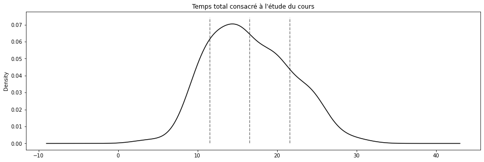

```python
t1 = data = df["Temps total consacré à l'étude du cours (en présence des enseignants ou non)"]
color="black"
label=None
data.plot.kde(color=color)
m, s = np.nanmean(data), np.nanstd(data)
bottom, top = pp.gca().get_ylim()
pp.plot([m, m], [0.0, top], "--", color=color, alpha=0.5)
pp.plot([m-s, m-s], [0.0, top], "--", color=color, alpha=0.5)
pp.plot([m+s, m+s], [0.0, top], "--", color=color, alpha=0.5)
pp.title("Temps total consacré à l'étude du cours")
```

```python
li = df["Temps total consacré aux exercices (en présence des enseignants ou non)"].tolist()
l = ['12',
'13',
'24',
'12',
'16',
'15',
'14',
'20',
'22',
nan,
"En fichant je fais tous les exercices essentiels, je fais les avancés lorsque j'ai relu mon cours et que je pense le maîtriser",
'12',
'15',
'20',
'24',
'15',
'12',
'12',
'15',
'12',
'14',
'16',
'17',
'22',
nan,
'12',
'20',
'15',
'12',
nan,
'27.5',
'17',
'20',
'12',
'18',
'16',
'18',
'14',
'12',
'24',
'13',
'3',
nan,
'17',
'10',
'15',
'14.5',
'12',
'18',
'16.5 ',
nan,
'12',
'13.5',
'24',
'12',
'14',
'14',
'26',
"15",
'12',
'15',
'16',
'24',
'14',
"12",
'23',
"Non mesuré  probablement dans la moyenne conseillée (un peu de préparation à l'avance)",
'30',
'Idem',
'12',
'17',
'16',
'20',
'12',
'24',
'25',
"15",
'12',
'14',
'20',
'12',
'18',
'24',
'13',
'24',
nan,
'20',
'30',
'12',
'18',
'20',
'24',
'12',
'12',
'12',
nan,
'20',
nan,
'12',
'17',
'15',
'16',
'13.5',
'16',
"18",
'12',
'30']
time_old_new = []
for i, x in enumerate(l):
   try:
       l[i] = float(x)
   except:
       l[i] = np.nan
   time_old_new.append([li[i], l[i]])

t2 = df["Temps total consacré aux exercices (en présence des enseignants ou non)"] = l
with pd.option_context('display.max_rows', None, 'display.max_columns', None):
   display(pd.DataFrame(time_old_new, columns=["Original", "Transcrit"]))
```

|  | Original | Transcrit |
| --- | --- | --- |
| 0 | 12 | 12.0 |
| 1 | 13h | 13.0 |
| 2 | 24 | 24.0 |
| 3 | 12h | 12.0 |
| 4 | 16 | 16.0 |
| 5 | 15h | 15.0 |
| 6 | 14 | 14.0 |
| 7 | 20 | 20.0 |
| 8 | 22 | 22.0 |
| 9 | NaN | NaN |
| 10 | En fichant je fais tous les exercices essentie... | NaN |
| 11 | 12h | 12.0 |
| 12 | 12h de TD + 3h perso = 15h | 15.0 |
| 13 | 20h | 20.0 |
| 14 | 24 | 24.0 |
| 15 | 15 | 15.0 |
| 16 | 12h | 12.0 |
| 17 | 12 | 12.0 |
| 18 | 15h | 15.0 |
| 19 | 12h | 12.0 |
| 20 | 14h | 14.0 |
| 21 | 16h | 16.0 |
| 22 | 17h (quelques exercices refaits à la maison) | 17.0 |
| 23 | 10h en plus des TD | 22.0 |
| 24 | NaN | NaN |
| 25 | 12 | 12.0 |
| 26 | 20h | 20.0 |
| 27 | 15h | 15.0 |
| 28 | 12h | 12.0 |
| 29 | NaN | NaN |

[output cut: 77 more lines]

```python
np.nanmean(l)
```

```
16.609375
```

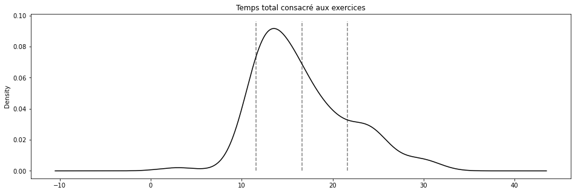

```python
t2 = data = df["Temps total consacré aux exercices (en présence des enseignants ou non)"]
color="black"
label=None
data.plot.kde(color=color)
m, s = np.nanmean(data), np.nanstd(data)
bottom, top = pp.gca().get_ylim()
pp.plot([m, m], [0.0, top], "--", color=color, alpha=0.5)
pp.plot([m-s, m-s], [0.0, top], "--", color=color, alpha=0.5)
pp.plot([m+s, m+s], [0.0, top], "--", color=color, alpha=0.5)
pp.title("Temps total consacré aux exercices")
```

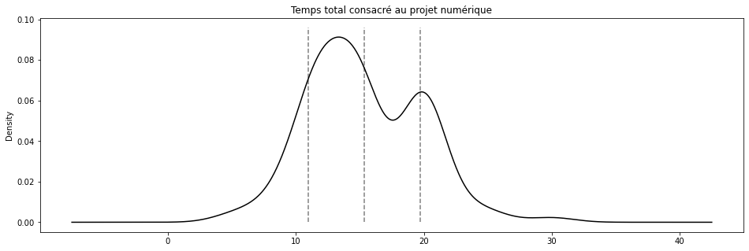

```python
t3 = data = l = df["Temps total consacré au projet numérique (en présence des enseignants ou non)"]
color="black"
label=None
data.plot.kde(color=color)
m, s = np.nanmean(data), np.nanstd(data)
bottom, top = pp.gca().get_ylim()
pp.plot([m, m], [0.0, top], "--", color=color, alpha=0.5)
pp.plot([m-s, m-s], [0.0, top], "--", color=color, alpha=0.5)
pp.plot([m+s, m+s], [0.0, top], "--", color=color, alpha=0.5)
pp.xticks([0, 10, 20, 30, 40])
pp.title("Temps total consacré au projet numérique")
```

```python
np.nanmean(l)
```

```
15.331683168316832
```

```
moyenne : 44.12322695035461 , écart-type : 9.438159811477052
```

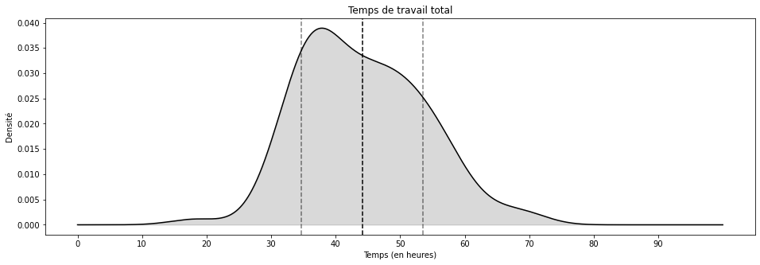

```python
t = t1 + t2 + 0.5 * t3 + 3.0 + 1/3 # added exams, substracted CS part in project (half)
#t.plot.kde(color=color)
t = t[t.notnull()]
k = st.gaussian_kde(t)
h = np.linspace(0, 100, 1000)
color = "black"
pp.plot(h, k(h), color)
pp.fill_between(h, np.zeros_like(h), k(h), color=color, alpha=0.15)
m, s = np.nanmean(t), np.nanstd(t)
print("moyenne :", m, ", écart-type :", s)
bottom, top = pp.gca().get_ylim()
left, right = pp.gca().get_xlim()
pp.plot([m, m], [bottom, top], "--", color=color)
pp.plot([m-s, m-s], [bottom, top], "--", color=color, alpha=0.5)
pp.plot([m+s, m+s], [bottom, top], "--", color=color, alpha=0.5)
pp.axis([left, right, bottom, top])
ticks = np.r_[0:100:10]
pp.title("Temps de travail total")
pp.xlabel("Temps (en heures)")
pp.ylabel("Densité")
_ = pp.xticks(ticks)
```

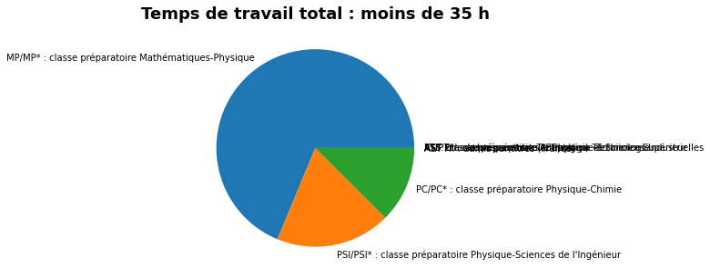

```python
dfi = df.loc[t[t <= 35].index]
origin = dfi["Filière d'origine"]
_ = pp.pie([len([item for item in origin if item == label]) for label in labels], labels=labels)
_ = pp.gca().set_title("Temps de travail total : moins de 35 h", fontweight="bold", fontsize=18)
```

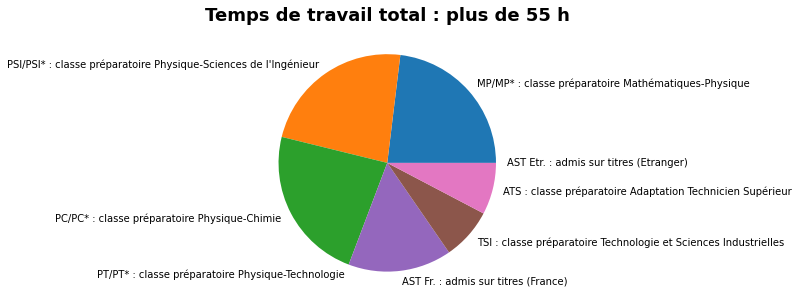

```python
dfi = df.loc[t[t >= 55].index]
origin = dfi["Filière d'origine"]
_ = pp.pie([len([item for item in origin if item == label]) for label in labels], labels=labels)
_ = pp.gca().set_title("Temps de travail total : plus de 55 h", fontweight="bold", fontsize=18)
```

## Equipe pédagogique

**Satisfaction moyenne vis-à-vis du travail des enseignants.** Le calcul n'est **pas** explicitement pondéré par le nombre d'heures fait par les enseignants (chaque appréciation donnée ayant le même poids). Mais les enseignants ayant vu le plus souvent les élèves et surtout un nombre d'élèves plus grand sont susceptibles d'avoir plus d'appréciations de leur part, et donc indirectement un poids plus important dans le calcul.

Au final, avec ce mode de calcul, 90% des étudiants apparaissent comme plutôt ou tout à fait satisfaits du travail de l'équipe pédagogique, contre 10% des étudiants qui semblent peu ou pas satisfaits.

|  | Satisfaction |
| --- | --- |
| Non, pas du tout | 2.5 |
| Plutôt non | 7.5 |
| Plutôt oui | 21.5 |
| Oui, tout à fait | 68.5 |

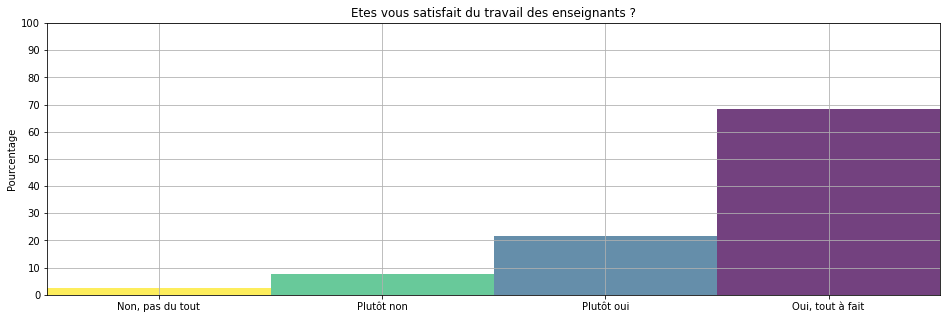

```python
teachers = "Toutes modalités confondues, êtes-vous satisfait du travail des enseignants"
all_teachers = [key for key in df.columns.values if key.startswith(teachers)]
#a = df[all_teachers].value_counts()
results = df[all_teachers].apply(pd.value_counts).sum(axis=1) # series
total = results.sum()
percentage = pd.DataFrame({"Satisfaction" : results.apply(lambda s: round(s / total * 100, 2))})
answers = ["Non, pas du tout", "Plutôt non", "Plutôt oui", "Oui, tout à fait"]
percentage = percentage.reindex(answers)
display(percentage)

colormap="viridis"
alpha=0.75
invert=True
n = len(answers)
index = list(range(n))
pp.xticks(index, answers)
pp.axis([-0.5, n-0.5, 0, 100])
pp.grid(True)
pp.ylabel("Pourcentage")
pp.yticks(np.linspace(0, 100, 11))
colormap = cm.get_cmap(colormap)
xrange = np.linspace(0.0, 1.0, n)
if invert:
    xrange = 1.0 - xrange
colors = [colormap(x) for x in xrange]
_ = pp.bar(index, percentage["Satisfaction"], width=1.0, color=colors, alpha=alpha)
_ = pp.title("Etes vous satisfait du travail des enseignants ?")
```